# Data Wrangling

### Exercise 1

```r
filter(flights, month == 3, day == 17)
filter(flights, dest == "ORD")
filter(flights, dest == "ORD", carrier == "UA")
filter(flights, distance > 2000 | air_time > 5 * 60)
```

### Exercise 2

```r
flights2 <- mutate(flights, speed = distance/(air_time/60))
speed <- select(flights2, tailnum, speed)
```

### Exercise 3

```r
flights %>%
  group_by(carrier) %>%
  summarize(avg_delay = mean(dep_delay, na.rm = TRUE)) %>%
  arrange(desc(avg_delay))
```

```
## Source: local data frame [11 x 2]
##
##    carrier avg_delay
##      (chr)     (dbl)
## 1       WN 13.329137
## 2       AA 10.597632
## 3       F9 10.152473
## 4       UA  9.795162
## 5       B6  8.462857
## 6       VX  7.852158
## 7       DL  4.820384
## 8       OO  4.435644
## 9       AS  2.783932
## 10      US  2.734850
## 11      HA  2.580439
```

*The highest mean delay is with Southwest and the lowest is with Hawaiian Airlines.*

## On your own

For the following questions, it may be helpful to sketch out what you want the final data set to look like (what are the rows? what are the columns?), then work backwards to figure out how to create that dataset from the original data.

- The plot below displays the relationship between the mean arrival delay and the mean distance travelled by every plane in the data set. It also shows the total number of flights made by each plane by the size of the plotted circle. Please form the chain necessary to create the dataset that lies underneath this plot. You will also want to exclude the edge cases from your analysis, so focus on the planes that have logged more than 20 flights and flown an average distance of less than 2000 miles.

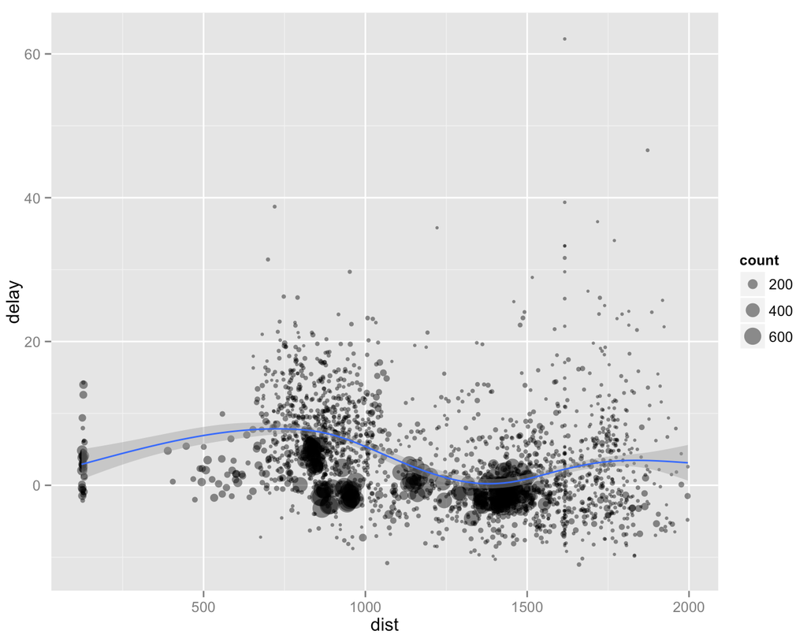

```r
delay <- flights %>%
  group_by(tailnum) %>%
  summarize(count = n(),
            delay = mean(arr_delay, na.rm = TRUE),
            dist = mean(distance)) %>%
  filter(count > 20, dist < 2000)
```

- Once you have that dataset, you can check your answer by using the following code to generate the plot. What does the relationship appear to be between mean distance that planes fly and their mean arrival delay?

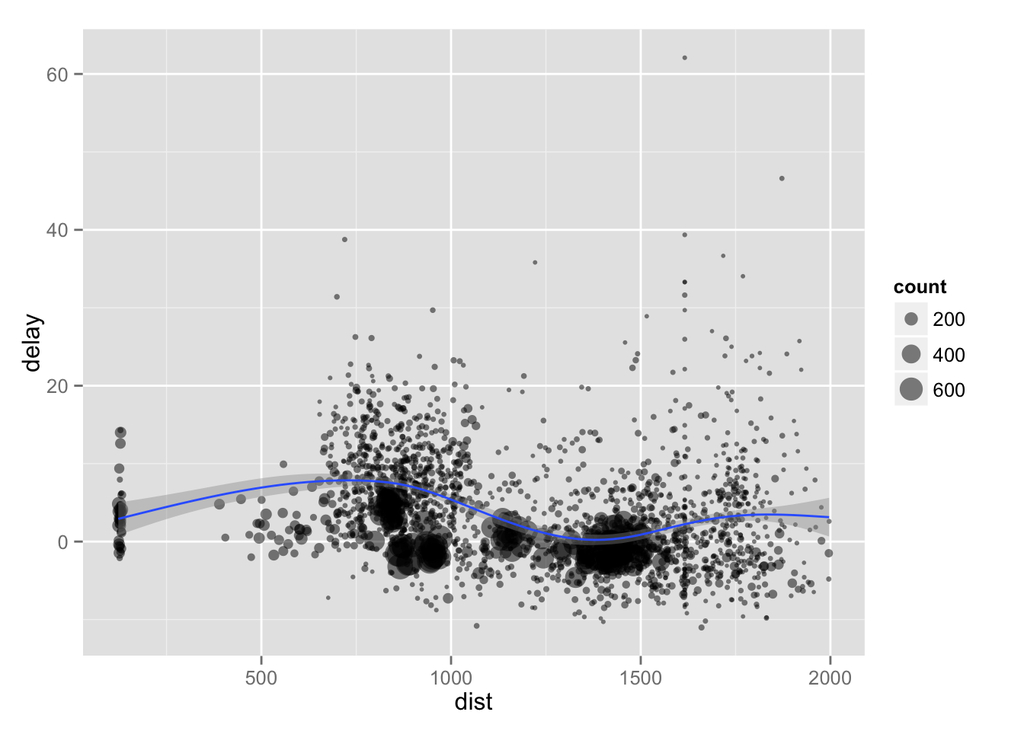

```r
ggplot(delay, aes(dist, delay)) +
 geom_point(aes(size = count), alpha = 1/2) +
 geom_smooth() +
 scale_size_area()
```

*Planes that fly just shy of 1000 miles tend to have the highest arrival delays on average. Planes making longer flights (around 1500 miles) have fewer arrival delays on average. This is somewhat surprising. It may suggest that if there has been a departure delay, the plane is able to make up more of the lost time if it tends to make longer flights. Other explanations are possible, though, including carrier as a confounder. Southwest makes primarily regional flights and we saw earlier that they have the highest mean departure delay, so their planes might be making up the majority of the sub-1000 mile planes.*

- Say you live halfway between Portland and Seattle. Based on the 2014 data, which airport should you fly out of to minimize overall delays? (however you define them)

```r
flights %>%
  # this is one possible measure of overall delay
  mutate(tot_delay = dep_delay + arr_delay) %>%
  group_by(origin) %>%
  summarize(avg_tot_delay = mean(tot_delay, na.rm = TRUE))
```

```
## Source: local data frame [2 x 2]
##
##   origin avg_tot_delay
##    (chr)         (dbl)
## 1    PDX      7.388994
## 2    SEA      8.820187
```

*According to my measure of overall delay, the 2014 suggests that PDX had a lower mean overall delay at 7.39 minutes versus 8.82 for Seattle, so I’d fly out of PDX.*

- Say you fly very often between PDX airport in Portland and JFK airport in New York. Which day of the week would you recommend that I buy a ticket for if I want to minimize delays? Any tips for the best airlines to go through?

```r
flights %>%
  filter(origin == "PDX", dest == "JFK") %>%
  mutate(date = as.Date(paste(month, day, year, sep = "-" ), "%m-%d-%Y")) %>%
  mutate(day_of_week = weekdays(date)) %>%
  group_by(day_of_week) %>%
  summarize(count = n(), delay = mean(arr_delay, na.rm = TRUE)) %>%
  arrange(delay)
```

```
## Source: local data frame [7 x 3]
##
##   day_of_week count    delay
##         (chr) (int)    (dbl)
## 1      Monday   137 2.157895
## 2    Saturday    90 2.443182
## 3      Friday   137 4.216418
## 4   Wednesday   109 5.250000
## 5    Thursday   136 6.389313
## 6      Sunday   136 6.567164
## 7     Tuesday   109 7.669811
```

*If you define delays as the arrival delay, then you’d be best served by traveling on a Monday or a Saturday.*

```r
flights %>%
  filter(origin == "PDX", dest == "JFK") %>%
  group_by(carrier) %>%
  summarize(count = n(), delay = mean(arr_delay, na.rm = TRUE)) %>%
  arrange(delay)
```

```
## Source: local data frame [2 x 3]
##
##   carrier count    delay
##     (chr) (int)    (dbl)
## 1      DL   546 3.431262
## 2      B6   308 7.729373
```

**Challenge**: Remake two plots that show up in the slides - the points plot of average delays by carrier and the bar chart of total count of flights by carrier out of PDX - but display the carriers in descending order.

*There are many ways to do this. Here are two possibilities.*

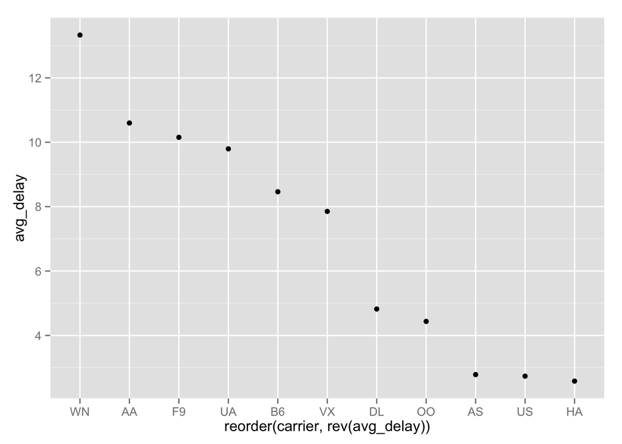

```r
flights %>%
  group_by(carrier) %>%
  summarize(avg_delay = mean(dep_delay, na.rm = TRUE)) %>%
  arrange(avg_delay) %>%
  qplot(x = reorder(carrier, rev(avg_delay)), y = avg_delay, data = ., geom = "point")
```

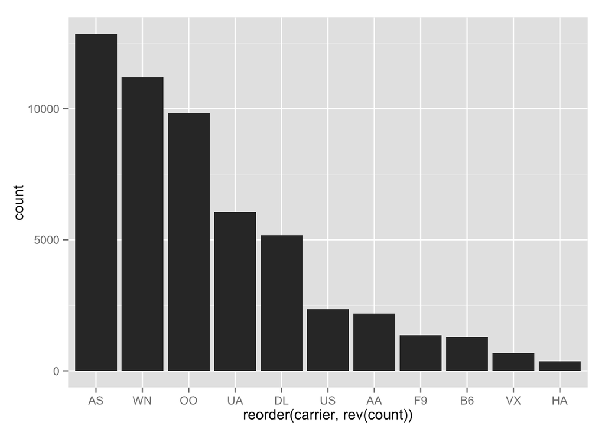

```r
flights %>%
  filter(origin == "PDX") %>%
  group_by(carrier) %>%
  summarize(count = n()) %>%
  arrange(count) %>%
  qplot(x = reorder(carrier, rev(count)), y = count, data = .,
        stat = "identity", geom = "bar")
```